# 2_1_feature_engineering

В данном блоке начинается процесс по приведению датасета в вид, пригодный для обучения модели

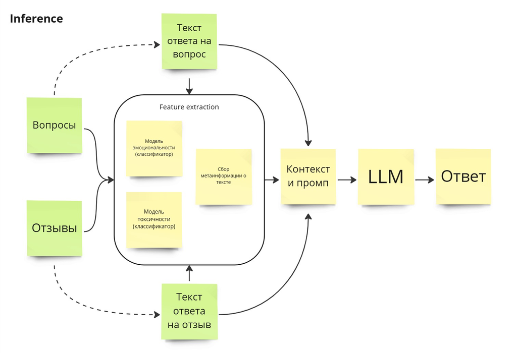

Основная того, как модель будет работать по итогу - мы передаем в модель не только изначальный текст, но так же и дополнительную информаци:

- Класс токсичности, опрделенный сторонней моделью
- Класс эмоциональности, определенный сторонней моделью
- Информация о продукте (Описание товара, магазин, категория, это Отзыв или Вопрос и тд.)

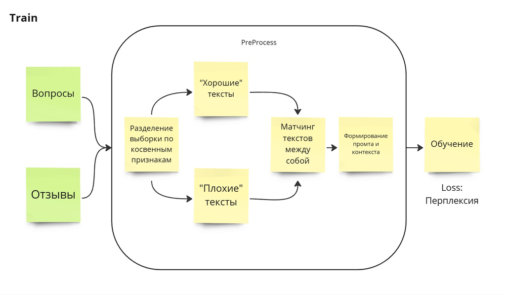

Для того, чтоюы модель работала по такому механизму её нужно дообучить на корпусе, состоящем из изначального текста и текста, который мы хотим получить в итоге

Так как у нас есть просто набор текстов, нужно изначально выделить "Плохие" тексты (токсичные, негативные излишне депрессивные), которые мы будем менять, и "Хорошие" тексты (в основном нейтральные, но могут быть и позитивными), которые будут для нас таргетом

После этого мы должны найти ближайшие тексты по смыслу из группы "Хороших" на каждый "Плохой" текст, с помошью матчинга

```python
import random
from datasets import load_dataset
from transformers import AutoTokenizer, pipeline
from optimum.onnxruntime import ORTModelForSequenceClassification
from sentence_transformers import SentenceTransformer
```

Классификация по эмоциональности и токсичности, понадобиться дальше для формирование промта и подбора обучающей выборки

*Решил протестировать скорость работы optimum'а с Onnx в бекенде

```python
def load_calssif(name: str):
    return pipeline(
        task='text-classification',
        model=ORTModelForSequenceClassification.from_pretrained(
            name,
            export=True,
            provider="CUDAExecutionProvider",
            use_io_binding=True
        ), # type: ignore
        tokenizer=AutoTokenizer.from_pretrained(
            name,
            useFast=True
        ),
        device='cuda:0'
    )
```

```python
ds = load_dataset('Roaoch/urfu_ecom_wb', split='train')

ds
```

```
Dataset({
    features: ['nmId', 'text', 'responder', 'type', 'product_name', 'product_category_2', 'product_category_1', 'product_color', 'product_description', 'product_brand', '__index_level_0__'],
    num_rows: 1914329
})
```

```python
ds = ds.train_test_split( # type: ignore
    test_size=0.25,
    shuffle=True
)

ds
```

```
DatasetDict({
    train: Dataset({
        features: ['nmId', 'text', 'responder', 'type', 'product_name', 'product_category_2', 'product_category_1', 'product_color', 'product_description', 'product_brand', '__index_level_0__'],
        num_rows: 1435746
    })
    test: Dataset({
        features: ['nmId', 'text', 'responder', 'type', 'product_name', 'product_category_2', 'product_category_1', 'product_color', 'product_description', 'product_brand', '__index_level_0__'],
        num_rows: 478583
    })
})
```

```python
tox_class_pipe = load_calssif('cointegrated/rubert-tiny-toxicity')
```

```python
emot_class_pipe = load_calssif('cointegrated/rubert-tiny2-cedr-emotion-detection')
```

Для матчинга нам нужно вытянуть вектор предложения, для чего буду использовать Sentence-transformers, так же с бекендом в виде Onnx

```python
vecorizer = SentenceTransformer(
    'sentence-transformers/paraphrase-multilingual-MiniLM-L12-v2',
    backend='onnx'
)
```

[output not shown]

[output not shown]

Обрабатываем тренировочные тексты моделям, тестовый набор оставляем для валидации в конце

```python
def predict(row):
    return {
        **row,
        'vector': vecorizer.encode(row['text'][:vecorizer.max_seq_length]),
        'toxicity': tox_class_pipe(row['text'][:tox_class_pipe.tokenizer.model_max_length])[0]['label'], # type: ignore
        'emotions': emot_class_pipe(row['text'][:emot_class_pipe.tokenizer.model_max_length])[0]['label'] # type: ignore
    }


ds['train'] = ds['train'].map(
    predict
)

ds
```

```
DatasetDict({
    train: Dataset({
        features: ['nmId', 'text', 'responder', 'type', 'product_name', 'product_category_2', 'product_category_1', 'product_color', 'product_description', 'product_brand', '__index_level_0__', 'vector', 'toxicity', 'emotions'],
        num_rows: 1435746
    })
    test: Dataset({
        features: ['nmId', 'text', 'responder', 'type', 'product_name', 'product_category_2', 'product_category_1', 'product_color', 'product_description', 'product_brand', '__index_level_0__'],
        num_rows: 478583
    })
})
```

```python
ds['train'].to_parquet('./__output__/train.parquet')
ds['test'].to_parquet('./__output__/test.parquet')
```

```
846985890
```

```python
ds['train'][random.randint(0, len(ds['train']))]
```

[output not shown]

[output cut: 342 more lines]

[output not shown]

# 2_2_matching

Здесь мы определяем правила деления текстов на группы, а так же матчим группы между собой

```python
import torch
import matplotlib.pyplot as plt
import pandas as pd
import numpy as np
from datasets import Dataset
from sklearn.manifold import TSNE
from sentence_transformers.util import normalize_embeddings, semantic_search
from tqdm import tqdm

tqdm.pandas()
```

## EDA

В этом разделе мы исследуем данные, которые у нас получились, чтобы разделить тексты на группы

* EDA - Exploratory data analysis

```python
df = pd.read_parquet('./__output__/train.parquet')
df = df[df['text'] != '']

df.head()
```

|  | nmId | text | responder | type | product_name | product_category_2 | product_category_1 | product_color | product_description | product_brand | __index_level_0__ | vector | toxicity | emotions |
| --- | --- | --- | --- | --- | --- | --- | --- | --- | --- | --- | --- | --- | --- | --- |
| 0 | 7758359 | У меня сложилось впечатлением, что это Lovular... | Клиент | Отзыв | Трусики-подгузники, Travel pack, XL 12-20 кг. ... | Подгузники детские | Товары для малышей | мятный, белый | В упаковке 3 шт подгузников-трусиков в 3 разны... | Offspring | 244202 | [0.035206687, -0.017458411, 0.050057203, 0.156... | non-toxic | no_emotion |
| 1 | 3691804 | Добрый день! Благодарим за интерес, проявленны... | Магазин | Вопрос | HEPA фильтр FTH 08 для пылесосов SAMSUNG (Самс... | Фильтры для пылесосов | Бытовая техника | черный | Filtero FTH 08 НЕРА фильтр для пылесоса SAMSUN... | Filtero | 1830972 | [-0.08458676, -0.043620594, 0.0068595554, 0.02... | non-toxic | joy |
| 2 | 2148099 | От сандалий не осталось ничего!!! Ни цвета ни ... | Клиент | Отзыв | Сандалии | Сандалии | Обувь | бежевый |  | Flamingo | 313600 | [-0.12766595, 0.19042678, 0.28017798, 0.015342... | non-toxic | joy |
| 3 | 8023423 | Заказывала синий красный белый 46 размер,ткань... | Клиент | Вопрос | Сарафан | Сарафаны | Одежда | синий, ярко-красный | Летний сарафан на бретельках из 100% хлопка-ку... | Агапэ | 1158995 | [0.047446445, 0.32030234, 0.103780545, 0.00696... | non-toxic | no_emotion |
| 4 | 5956211 | Добрый день, Вы взяли один размер в одном рост... | Магазин | Вопрос | Медицинские брюки из Satory | Брюки медицинские | Спецодежда и СИЗы | ярко-зеленый | Медицинские брюки из ткани Сатори без стрейча,... | Med Fashion Lab | 1548250 | [0.10665777, 0.018597584, 0.17656998, 0.103213... | non-toxic | sadness |

```python
df['emotions'].value_counts()
```

```
emotions
no_emotion    569413
joy           563630
sadness        89155
surprise       65869
anger           8762
fear            5138
Name: count, dtype: int64
```

```python
df['toxicity'].value_counts()
```

```
toxicity
non-toxic    1298729
dangerous       2215
insult           743
threat           240
obscenity         40
Name: count, dtype: int64
```

Здесь видно, что используемые модели токсичности и эмоциональности не совершены, что является слабым местом итоговой модели, тем не менее в большей части случаев, все-таки результаты неплохи

```python
mask = (df['emotions'] == 'anger') | \
(df['emotions'] == 'fear') | \
(df['toxicity'] == 'dangerous') | \
(df['toxicity'] == 'insult') | \
(df['toxicity'] == 'threat') | \
(df['toxicity'] == 'obscenity')

pos_df = df[~mask]
neg_df = df[mask]

neg_df
```

|  | nmId | text | responder | type | product_name | product_category_2 | product_category_1 | product_color | product_description | product_brand | __index_level_0__ | vector | toxicity | emotions |
| --- | --- | --- | --- | --- | --- | --- | --- | --- | --- | --- | --- | --- | --- | --- |
| 104 | 7728617 | ДОБРОГО ВРЕМЕНИ СУТОК! БУДЬТЕ ДОБРЫ, ПОДСКАЖИТ... | Клиент | Вопрос | Футболка | Футболки | Одежда | белый |  | Gulliver | 1383398 | [0.17008908, 0.10877619, 0.05582178, -0.073754... | non-toxic | anger |
| 230 | 8359265 | Пишу повторный отзыв, проработал в итоге не бо... | Клиент | Отзыв | Светильник настольный аккумуляторный | Светильники | Дом | черный | Светильние настольный Ultraflash предназначен ... | Ultraflash | 128800 | [-0.023336649, -0.0033628214, 0.024340235, -0.... | non-toxic | anger |
| 322 | 3081307 | цвет темнее чем на фото. чашечка одна была зал... | Клиент | Отзыв | Купальник | Раздельные купальники | Белье | синий | Формованная чашка с гелевым пуш-апом на каркас... | FIANETA | 439944 | [0.03222534, 0.19630186, -0.07846444, 0.295757... | dangerous | no_emotion |
| 380 | 6144081 | В нее можно дуть,как в дудку,или это просто по... | Клиент | Вопрос | Погремушка Горн | Погремушки | Игрушки | зеленый | Погремушка в форме горна из пластмассы. Звук с... | Bampi | 1216858 | [0.08189797, -0.05039759, 0.10465885, 0.003125... | non-toxic | anger |
| 458 | 88636591 | Ужасные стекла ,брал на Poco X 3, не достаёт п... | Клиент | Отзыв | Защитное стекло для Poco X3/ X3 Pro/ F3 | Защитные стекла | Смартфоны и аксессуары | прозрачный | На все наши стекла распространяктся 40-дневная... | POCO | 409071 | [-0.14631407, -0.10690308, 0.31674215, 0.01058... | non-toxic | anger |
| ... | ... | ... | ... | ... | ... | ... | ... | ... | ... | ... | ... | ... | ... | ... |
| 1435269 | 43395620 | Отличные финики, крупные, вкусные и явно свежи... | Клиент | Отзыв | Финики сушеные 1 килограмм/Деглет Нур/Алжирские | Сухофрукты | Продукты |  | Финики сорта Деглет Нур с косточкой внутри. На... | Nu_Aa | 289814 | [0.03858127, -0.04472396, -0.041799344, 0.1706... | non-toxic | fear |
| 1435518 | 102324783 | нормально, для своей цены хороши, шнурки были... | Клиент | Отзыв | Кроссовки nike air force 1 форсы | Кроссовки | Обувь | белый, холодный белый, белый матовый | Кроссовки женские белые предназначены для несп... | KrossBox | 344721 | [-0.20296763, 0.060336113, 0.19069918, -0.0377... | non-toxic | anger |
| 1435684 | 5524454 | Здравствуйте! Приносим извинения за Ваш негати... | Магазин | Отзыв | Термопот настольный 4,5 л, кипятильник | Термопоты | Техника для кухни |  | Электрический кипятильник (термопот) Gemlux GL... | Gemlux | 522826 | [0.019145688, 0.030086005, 0.15169105, 0.09666... | non-toxic | anger |
| 1435715 | 115456518 | Когда-то давно купила точно такой набор, но со... | Клиент | Отзыв | Набор из 6 тарелок в форме рыбок 19.6 х 16 см | Тарелки | Посуда и инвентарь | прозрачный | Блюдо фигурное Pasabahce Marine. Набор из шест... | Pasabahce | 180949 | [-0.1364429, -0.051336, 0.16248755, 0.00368038... | non-toxic | anger |
| 1435728 | 5336375 | сколько ещё будет идти проверка??? wb 2 недели... | Клиент | Вопрос | Кеды | Кеды | Обувь | белый |  | KEDDO | 1209350 | [-0.10596211, 0.09651265, 0.016850276, -0.1688... | non-toxic | anger |

16830 rows × 14 columns

Для отрисовки, формируем сабсет

Так же, в ходе тестов, менял разные параметры, которые отрисовывал, из которых в общем-то можно сделать один вывод - в большай части случаев значение одного поля более менее равномерно распределено по облаку векторных представлений

```python
subset = neg_df.sample(5000)
manifolder = TSNE(n_components=2)
```

```python
vectors = np.array(subset['vector'].to_list())
vectors = manifolder.fit_transform(vectors)
```

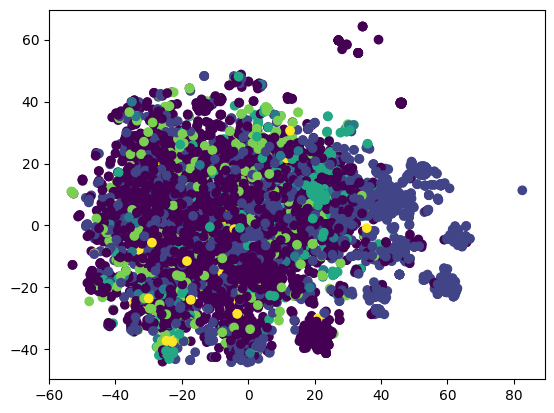

```python
field = 'emotions'

mapper = {e: i for i, e in enumerate(subset[field].unique())}

plt.scatter(
    vectors[:, 0],
    vectors[:, 1],
    c=subset[field].apply(lambda e: mapper[e])
)

plt.show()
```

## Матчинг негатива с нормой

```python
corpus = torch.FloatTensor(
    np.array(pos_df['vector'].to_list())
).to('cuda:0')

corpus = normalize_embeddings(corpus)
```

```python
semantic_search(
    normalize_embeddings(
        torch.FloatTensor([neg_df.iloc[0]['vector']]).to('cuda:0')
    ),
    corpus
)
```

```
[[{'corpus_id': 72695, 'score': 0.8217299580574036},
  {'corpus_id': 1228083, 'score': 0.8149760365486145},
  {'corpus_id': 29511, 'score': 0.806286096572876},
  {'corpus_id': 974155, 'score': 0.8056544661521912},
  {'corpus_id': 323691, 'score': 0.8056530356407166},
  {'corpus_id': 326117, 'score': 0.8037558794021606},
  {'corpus_id': 655443, 'score': 0.8020350933074951},
  {'corpus_id': 608567, 'score': 0.8016837239265442},
  {'corpus_id': 586947, 'score': 0.7988957166671753},
  {'corpus_id': 536231, 'score': 0.7975293397903442}]]
```

```python
neg_df.iloc[0]['text']
```

```
'ДОБРОГО ВРЕМЕНИ СУТОК! БУДЬТЕ ДОБРЫ, ПОДСКАЖИТЕ , ПОЖАЛУЙСТА БУДЕТ ЛИ В НАЛИЧИИ В БЛИЖАЙШЕЕ ВРЕМЯ РАЗМЕР 158 ИЛИ 164? ЖДУ ОТВЕТА. ЗАРАНЕЕ БЛАГОДАРЮ ВАС ЗА ПОМОЩЬ.'
```

```python
pos_df.iloc[72695]['text']
```

```
'Здравствуйте , на размер 158 когда будет ожидаться? Или ожидается ли вообще?'
```

Изначально планировал искать матчи для негатива только из позитивных с тем же товаром, типом и респондентом, но из-за того, что пересечений между nmId у негатива и позитива недостаточно большое, пришлось матчить всех со всеми Отбрасывать неудобные негативные тексты, так же не подходить, так как наш датасет уже и так достаточно мал

```python
def get_match(e: np.ndarray):
    res = semantic_search(
        normalize_embeddings(
            torch.FloatTensor([e]).to('cuda:0')
        ),
        corpus,
        top_k=1
    )[0]
    return res[0]['corpus_id'] # type: ignore
```

```python
neg_df['target'] = neg_df['vector'].progress_apply(get_match)

neg_df
```

[output not shown]

|  | nmId | text | responder | type | product_name | product_category_2 | product_category_1 | product_color | product_description | product_brand | __index_level_0__ | vector | toxicity | emotions | target |
| --- | --- | --- | --- | --- | --- | --- | --- | --- | --- | --- | --- | --- | --- | --- | --- |
| 104 | 7728617 | ДОБРОГО ВРЕМЕНИ СУТОК! БУДЬТЕ ДОБРЫ, ПОДСКАЖИТ... | Клиент | Вопрос | Футболка | Футболки | Одежда | белый |  | Gulliver | 1383398 | [0.17008908, 0.10877619, 0.05582178, -0.073754... | non-toxic | anger | 72695 |
| 230 | 8359265 | Пишу повторный отзыв, проработал в итоге не бо... | Клиент | Отзыв | Светильник настольный аккумуляторный | Светильники | Дом | черный | Светильние настольный Ultraflash предназначен ... | Ultraflash | 128800 | [-0.023336649, -0.0033628214, 0.024340235, -0.... | non-toxic | anger | 1258620 |
| 322 | 3081307 | цвет темнее чем на фото. чашечка одна была зал... | Клиент | Отзыв | Купальник | Раздельные купальники | Белье | синий | Формованная чашка с гелевым пуш-апом на каркас... | FIANETA | 439944 | [0.03222534, 0.19630186, -0.07846444, 0.295757... | dangerous | no_emotion | 678951 |
| 380 | 6144081 | В нее можно дуть,как в дудку,или это просто по... | Клиент | Вопрос | Погремушка Горн | Погремушки | Игрушки | зеленый | Погремушка в форме горна из пластмассы. Звук с... | Bampi | 1216858 | [0.08189797, -0.05039759, 0.10465885, 0.003125... | non-toxic | anger | 640683 |
| 458 | 88636591 | Ужасные стекла ,брал на Poco X 3, не достаёт п... | Клиент | Отзыв | Защитное стекло для Poco X3/ X3 Pro/ F3 | Защитные стекла | Смартфоны и аксессуары | прозрачный | На все наши стекла распространяктся 40-дневная... | POCO | 409071 | [-0.14631407, -0.10690308, 0.31674215, 0.01058... | non-toxic | anger | 769857 |
| ... | ... | ... | ... | ... | ... | ... | ... | ... | ... | ... | ... | ... | ... | ... | ... |
| 1435269 | 43395620 | Отличные финики, крупные, вкусные и явно свежи... | Клиент | Отзыв | Финики сушеные 1 килограмм/Деглет Нур/Алжирские | Сухофрукты | Продукты |  | Финики сорта Деглет Нур с косточкой внутри. На... | Nu_Aa | 289814 | [0.03858127, -0.04472396, -0.041799344, 0.1706... | non-toxic | fear | 115744 |
| 1435518 | 102324783 | нормально, для своей цены хороши, шнурки были... | Клиент | Отзыв | Кроссовки nike air force 1 форсы | Кроссовки | Обувь | белый, холодный белый, белый матовый | Кроссовки женские белые предназначены для несп... | KrossBox | 344721 | [-0.20296763, 0.060336113, 0.19069918, -0.0377... | non-toxic | anger | 1262563 |
| 1435684 | 5524454 | Здравствуйте! Приносим извинения за Ваш негати... | Магазин | Отзыв | Термопот настольный 4,5 л, кипятильник | Термопоты | Техника для кухни |  | Электрический кипятильник (термопот) Gemlux GL... | Gemlux | 522826 | [0.019145688, 0.030086005, 0.15169105, 0.09666... | non-toxic | anger | 482053 |
| 1435715 | 115456518 | Когда-то давно купила точно такой набор, но со... | Клиент | Отзыв | Набор из 6 тарелок в форме рыбок 19.6 х 16 см | Тарелки | Посуда и инвентарь | прозрачный | Блюдо фигурное Pasabahce Marine. Набор из шест... | Pasabahce | 180949 | [-0.1364429, -0.051336, 0.16248755, 0.00368038... | non-toxic | anger | 639975 |
| 1435728 | 5336375 | сколько ещё будет идти проверка??? wb 2 недели... | Клиент | Вопрос | Кеды | Кеды | Обувь | белый |  | KEDDO | 1209350 | [-0.10596211, 0.09651265, 0.016850276, -0.1688... | non-toxic | anger | 1221527 |

16830 rows × 15 columns

Так-же, чтобы учитывать в выборке тексты, которые не нужно изменять, добавим в выборку данные из pos_df

*В ходе обучения моделей, будет замечано, что добавление этих данных в датасет, приводит к переобучению модели (модель просто начинает копировать изначальный текст)

```python
pos_df['target'] = range(len(pos_df))

matched_df = pd.concat([
    neg_df,
    pos_df.sample(int(len(neg_df)*0.33))
])

matched_df
```

|  | nmId | text | responder | type | product_name | product_category_2 | product_category_1 | product_color | product_description | product_brand | __index_level_0__ | vector | toxicity | emotions | target |
| --- | --- | --- | --- | --- | --- | --- | --- | --- | --- | --- | --- | --- | --- | --- | --- |
| 0 | 7728617 | ДОБРОГО ВРЕМЕНИ СУТОК! БУДЬТЕ ДОБРЫ, ПОДСКАЖИТ... | Клиент | Вопрос | Футболка | Футболки | Одежда | белый |  | Gulliver | 1383398 | [0.17008908, 0.10877619, 0.05582178, -0.073754... | non-toxic | anger | 72695 |
| 1 | 8359265 | Пишу повторный отзыв, проработал в итоге не бо... | Клиент | Отзыв | Светильник настольный аккумуляторный | Светильники | Дом | черный | Светильние настольный Ultraflash предназначен ... | Ultraflash | 128800 | [-0.023336649, -0.0033628214, 0.024340235, -0.... | non-toxic | anger | 1258620 |
| 2 | 3081307 | цвет темнее чем на фото. чашечка одна была зал... | Клиент | Отзыв | Купальник | Раздельные купальники | Белье | синий | Формованная чашка с гелевым пуш-апом на каркас... | FIANETA | 439944 | [0.03222534, 0.19630186, -0.07846444, 0.295757... | dangerous | no_emotion | 678951 |
| 3 | 6144081 | В нее можно дуть,как в дудку,или это просто по... | Клиент | Вопрос | Погремушка Горн | Погремушки | Игрушки | зеленый | Погремушка в форме горна из пластмассы. Звук с... | Bampi | 1216858 | [0.08189797, -0.05039759, 0.10465885, 0.003125... | non-toxic | anger | 640683 |
| 4 | 88636591 | Ужасные стекла ,брал на Poco X 3, не достаёт п... | Клиент | Отзыв | Защитное стекло для Poco X3/ X3 Pro/ F3 | Защитные стекла | Смартфоны и аксессуары | прозрачный | На все наши стекла распространяктся 40-дневная... | POCO | 409071 | [-0.14631407, -0.10690308, 0.31674215, 0.01058... | non-toxic | anger | 769857 |
| ... | ... | ... | ... | ... | ... | ... | ... | ... | ... | ... | ... | ... | ... | ... | ... |
| 656650 | 8172469 | Добрый день! Длина 36см, ширина по талии 36см | Магазин | Вопрос | Юбка | Юбки | Одежда | синий | Юбка из расшитого хлопка, со сборкой по талии,... | ACOOLA | 1683663 | [0.28716046, 0.2006678, 0.016394911, -0.042199... | non-toxic | joy | 587753 |
| 169241 | 2561778 | Как мне оформить отказ от заказа под номером.1... | Клиент | Вопрос | Карандаш для губ Lasting Finish 1000 Kisses, т... | Косметические карандаши | Красота | темно-бежевый |  | Rimmel | 1305788 | [-0.13532826, 0.13940834, -0.16434129, 0.00734... | non-toxic | no_emotion | 151470 |
| 372172 | 10416573 | Внешне смотрятся хорошо. Удобные - на широкую ... | Клиент | Отзыв | Ботинки зимние/ натуральный мех | Ботинки | Обувь | синий | Бренд ZILFILD производит обувь ручной работы т... | ZILFILD | 431278 | [0.2490824, 0.30120248, -0.16389012, 0.0481176... | non-toxic | no_emotion | 333060 |
| 101302 | 3705090 | Здравствуйте! Костюм голубой-оранжевый пришел ... | Клиент | Вопрос | Костюм женский спортивный с начесом больших ра... | Костюмы спортивные | Спортивная одежда | серый | Костюм спортивный женский с начесом выполнен и... | Алтекс. | 1029842 | [0.117600515, 0.3701609, 0.097081475, 0.160216... | non-toxic | joy | 90604 |
| 920991 | 3256894 | Здравствуйте. Лампочка не гаснет. Заряжать маш... | Магазин | Вопрос | Машинка для стрижки волос ER131H520 | Машинки для стрижки волос | Бытовая техника | белый, серый | Электрическая машинка для стрижки волос, может... | Panasonic | 1548644 | [-0.09474845, 0.122863844, 0.25407657, 0.27802... | non-toxic | no_emotion | 824417 |

22383 rows × 15 columns

```python
pos_df = pos_df.add_prefix('target_')
pos_df = pos_df.rename({
    'target_target': 'target'
}, axis=1)
```

```python
matched_df = matched_df.merge(
    pos_df,
    how='left',
    on='target'
)

matched_df.sample(20)
```

|  | nmId | text | responder | type | product_name | product_category_2 | product_category_1 | product_color | product_description | product_brand | ... | target_product_name | target_product_category_2 | target_product_category_1 | target_product_color | target_product_description | target_product_brand | target___index_level_0__ | target_vector | target_toxicity | target_emotions |
| --- | --- | --- | --- | --- | --- | --- | --- | --- | --- | --- | --- | --- | --- | --- | --- | --- | --- | --- | --- | --- | --- |
| 6368 | 17460147 | Начиталась тут восторженных отзывов и заказала... | Клиент | Отзыв | Набор блесков для губ JUICY BOMB, малина т.02,... | Блески | Красота | нежный розовый | Мило, сочно и аппетитно!\nБлески для губ в наб... | essence. | ... | Туалетная вода Black Woman, 30 мл | Туалетная вода | Красота |  | Туалетная вода Mexx Black Woman - женский вост... | MEXX | 332776 | [-0.054779235, 0.038123984, -0.10523943, -0.06... | non-toxic | joy |
| 20691 | 7941127 | Добрый день! 62.5см | Магазин | Вопрос | Худи | Худи | Одежда | черный |  | ТВОЕ | ... | Худи | Худи | Одежда | черный |  | ТВОЕ | 1490622 | [0.16105503, 0.22428848, 0.078267306, 0.105647... | non-toxic | joy |
| 11259 | 98475125 | Я в ужасе. Это даже сложно назвать шампунем, к... | Клиент | Отзыв | Шампунь Volume (Сьёсс), 450мл | Шампуни | Красота |  | Syoss Volume шампунь для тонких волос, лишенны... | SYOSS | ... | Детский шампунь для волос с пантенолом, 500 мл | Шампуни | Красота |  | Детский шампунь с пантенолом для мытья волос и... | Mein Kleines | 381940 | [-0.13685936, 0.0055928514, 0.1508353, 0.01269... | non-toxic | no_emotion |
| 7732 | 10748631 | Выяснилось что этот товар находится в списке н... | Клиент | Отзыв | Крышка универсальная (20-22-24 см) | Крышки | Посуда и инвентарь | черный | Крышка Сибирская посуда подходит в качестве ун... | Сибирская посуда | ... | Сушилка для белья АКРОБАТ | Сушилки для белья | Хозяйственные товары | белый | Компактная сушилка для белья Акробат немецкого... | Vileda | 457311 | [-0.11393828, 0.054598663, 0.087786146, -0.106... | non-toxic | no_emotion |
| 19717 | 6426893 | Добрый день! Возможен ли данный жилет в размер... | Клиент | Вопрос | Жилет | Жилеты | Одежда | светло-серый | Гобелен- тренд сезона 2019г. Удлиненный жилет ... | Val'Za | ... | Жилет | Жилеты | Одежда | светло-серый | Гобелен- тренд сезона 2019г. Удлиненный жилет ... | Val'Za | 1418669 | [0.26439115, 0.41409844, -0.06699665, 0.126468... | non-toxic | joy |
| 5030 | 15132549 | Качество отличное, как всегда. Но! Граждане, н... | Клиент | Отзыв | Постельное белье семейное сатин-твил BP-9 | Постельное белье | Дом | персиковый, бежевый | Постельное белье семейное СайлиД серия BP, тка... | СайлиД | ... | Пижама женская со штанами шелковая для сна дом... | Пижамы | Одежда | бежевый, черный | В чём секрет твоей пижамы ? \nНадевая шелковую... | Miss Angelika | 235909 | [-0.004584446, 0.32641628, 0.054883596, 0.0479... | non-toxic | joy |
| 16251 | 8554229 | Здравствуйте. Усадку не дают. | Магазин | Вопрос | Комплект штор Sophia 150х270 | Шторы интерьерные | Шторы и аксессуары | бежевый, золотистый | В комплект входят 2 полотна, каждое шириной 15... | АЧ-Лидер | ... | Брюки женские, зауженные, укороченные | Брюки | Одежда | королевский синий |  | OLBE | 1866061 | [0.14146525, 0.079997145, 0.17024392, 0.070782... | non-toxic | joy |
| 22234 | 2561751 | Здравствуйте! Тон помады совпадает с детальным... | Магазин | Вопрос | Питательная помада для губ PRALINE | Помады | Красота | лиловый, кирпично-красный, темно-розовый, блед... | Помада "PRALINE" с мягкой сливочной текстурой ... | DIVAGE | ... | Питательная помада для губ PRALINE | Помады | Красота | лиловый, кирпично-красный, темно-розовый, блед... | Помада "PRALINE" с мягкой сливочной текстурой ... | DIVAGE | 1801624 | [-0.0005683261, 0.11623776, -0.04728687, -0.04... | non-toxic | no_emotion |
| 7823 | 913585 | сегодня получила...слов нет!!! сотрудники обли... | Клиент | Отзыв | Часы | Часы наручные | Аксессуары | золотистый |  | GUESS | ... | Купальник раздельный женский жатка рубчик бикини | Костюмы купальные | Белье | черный, глубокий черный | Модный однотонный раздельный купальник в рубчи... | SEARINA | 448663 | [0.035099346, 0.17078242, 0.15547979, -0.06942... | non-toxic | no_emotion |
| 14068 | 3312880 | Здравствуйте. Заказала 3 щетки, на сумму более... | Клиент | Вопрос | Электрическая зубная щетка HX6322/HX6352 | Электрические зубные щетки | Бытовая техника | голубой, белый | Детская электрическая звуковая зубная щетка Ph... | Philips | ... | носхи домашние для отдыха спорта охота | Носки | Белье | черный | Оригинальный набор носков с надписями на подош... | Berchelli | 432355 | [0.018187722, 0.11791203, -0.09769638, -0.0454... | non-toxic | no_emotion |
| 10564 | 7316545 | подскажите пожалуйста номер краски estel пепе... | Клиент | Вопрос | Краска для волос PRINCESS ESSEX 10.16 60 мл | Краски для волос | Красота |  | Официальный представитель бренда Estel Profess... | ESTEL | ... | Краска для окрашивания волос DE LUXE HIGH BLON... | Краски для волос | Красота |  | Для осветления волос с нюансировкой цвета. Соз... | ESTEL | 1255153 | [-0.17307211, 0.41757753, -0.012745147, 0.1137... | non-toxic | joy |
| 13513 | 6167671 | хочу на -4,5привезите пожааааааалуйста!!!! | Клиент | Вопрос | Цветные контактные линзы Adria Elegant Gray -5... | Контактные линзы | Здоровье | серый | ADRIA Elegant (Адриа Элегант) - цветные контак... | Adria | ... | Штора "Моника. Льняная Линия" 145х260 | Шторы интерьерные | Шторы и аксессуары | серый, белый | Стильная штора "Моника" на скрытых петлях стан... | IZKOMODA | 1308442 | [-0.030786382, -0.018557994, 0.04853789, -0.13... | non-toxic | joy |
| 2973 | 13227426 | Упакован комод был ужасно. Выдали в драной, по... | Клиент | Отзыв | Комод деревянный для вещей | Комоды | Мебель | светло-серый, белый | Комод деревянный Лидер 13.108 - функциональное... | Моби | ... | Комплект нательный для малыша | Комплекты нательные для малышей | Одежда для малышей | мятный |  | Amante Kids | 203322 | [-0.06878834, 0.10091835, -0.046762284, -0.003... | non-toxic | no_emotion |
| 7162 | 18892534 | Хорошие бубенчики, все как в описании. Так их ... | Клиент | Отзыв | Бубенчики, размер 1 шт: 3,5 см, набор 2 шт, цв... | Аксессуары для рукоделия | Рукоделие | золотистый | Бубенчики, размер 1 шт: 3,5 см, набор 2 шт, цв... | Mindelia | ... | Жевательная грушка для собак сверхпрочная апор... | Игрушки для животных | Товары для животных | оранжевый, перламутрово-оранжевый | Крепкий, антивандальный апорт. Изготовлен по у... | BULLKA TOYS | 181970 | [-0.07250914, 0.041086104, 0.11871898, -0.1333... | non-toxic | no_emotion |
| 17490 | 6706706 | Добрый день. Партия от партии крем может отлич... | Магазин | Вопрос | Крем для век и кожи вокруг глаз 20 мл | Кремы | Красота |  | Антивозрастной Крем для век против морщин и те... | Бизорюк | ... | Крем для век и кожи вокруг глаз 20 мл | Кремы | Красота |  | Антивозрастной Крем для век против морщин и те... | Бизорюк | 1729419 | [-0.023492265, 0.0013030338, 0.13394886, 0.105... | non-toxic | no_emotion |
| 12682 | 6682645 | Очень стильная и необычная, на мой взгляд, сум... | Клиент | Отзыв | Сумка | Сумки | Аксессуары | черный | Сумка мужская с одним отделением на молнии с у... | Franchesco Mariscotti | ... | Куртка пальто демисезонная | Куртки | Одежда | серый, темно-оливковый | Верхняя демисезонная одежда от бренда Teplove ... | Teplove | 392872 | [0.0075759357, 0.40806252, -0.2063157, 0.10646... | non-toxic | no_emotion |
| 2795 | 39563385 | Вешалка не понравилась, очень хлипкая, не знаю... | Клиент | Отзыв | Вешалка складная/ Дорожная вешалка | Вешалки на дверь | Хранение вещей | оранжевый | Вешалка складная занимает минимум места , удоб... | PandaMimi | ... | Платье | Платья | Одежда | светло-бежевый |  | Barcelonica | 146512 | [0.16777503, 0.2292161, 0.1195227, 0.19651356,... | non-toxic | no_emotion |
| 19243 | 5486440 | а какой крем лучше подойдет после этого геля? | Клиент | Вопрос | Гель для умывания Матирующий с голубой глиной,... | Гели | Красота |  | Голубая глина оказывает абсорбирующее и антисе... | levrana | ... | Гель для умывания Матирующий с голубой глиной,... | Гели | Красота |  | Голубая глина оказывает абсорбирующее и антисе... | levrana | 1065434 | [-0.07653063, 0.044708494, 0.18565069, 0.02217... | non-toxic | no_emotion |
| 5108 | 9897714 | И этот кошмар стоит около 3000?!!! Так ещё за ... | Клиент | Отзыв | Сумка женская из натуральной кожи | Сумки | Аксессуары | синий |  | LILI accessories | ... | Подгузники детские размер XL 12-17 кг 48 шт | Подгузники детские | Товары для малышей | белый |  | Baby Family | 51306 | [-0.08026754, 0.15900072, -0.060291197, -0.013... | non-toxic | joy |
| 12091 | 52071910 | С платьем что-то не то… вроде и красивое, но к... | Клиент | Отзыв | Платье вечернее офисное мини с длинным рукавом | Платья | Одежда | морская волна, голубой | Женское вечернее платье для особых случаев. Ше... | Classy Lady | ... | Платье | Платья | Одежда | светло-бежевый | Платье отрезное ниже талии, горловина круглая,... | AYZE | 342352 | [0.20537134, 0.19719672, -0.082886346, 0.23793... | non-toxic | no_emotion |

20 rows × 29 columns

```python
matched_df[[
    'text',
    'target_text'
]].sample(20)
```

|  | text | target_text |
| --- | --- | --- |
| 14438 | прислали какое-то убожество. единственный подх... | Колье мне не понравилось. \nВо-первых не пришл... |
| 9676 | Отличный антисептик, радует что содержание изо... | Сам гель хороший понравился и по консистенции,... |
| 8112 | Не ожидала,что будет такой тонкой,нужно немног... | Заказывала темно-синего цвета и своего размера... |
| 2410 | Уважаемый магазин! Пожалуйста сделайте скидку ... | Уважаемый магазин, откуда вы берете такие цены... |
| 14218 | Ошейник для собак работает все 5 минут!!!! ... | Подошёл отлично. Ткань приятная. Брала чтобы з... |
| 20845 | Добрый день, скажите будет ли поступление 37 р... | Добрый день, скажите будет ли поступление 37 р... |
| 476 | Это какой то ужас! Ждала нормальной цены пол г... | Очень понравился светильник! Пришёл целый, в п... |
| 4857 | Здравствуйте. Страна производитель препората | Здравствуйте подскажите страну производитель |
| 15188 | Что за неуважение? Третий раз оправляю вопрос!... | Третий раз задаю вопрос продавцам,почему не от... |
| 16807 | Уважаемые сотрудники магазина.прошу проверить ... | Здравствуйте! Перед отправкой на склад вайлдбе... |
| 21888 | Отличная вещь. Подойдёт от 50 до 56 размера за... | Отличная вещь. Подойдёт от 50 до 56 размера за... |
| 10346 | Заплатила за возврат 100₽, из за того, что про... | Отвратительно! \nОтношение поставщиков хуже не... |
| 12591 | Здравствуйте! Ожидается ли в самое ближайшее в... | Здравствуйте. Ожидается ли поступление данного... |
| 9977 | Продолжаю..Пытаюсь из разносить, хожу по к... | Шикарнейшие легкие широкие штаны! Превзошли вс... |
| 10865 | ЗДРАВСТВУЙТЕ! КОГДА БУДЕТ В ПРОДАЖЕ 38 РАЗМ. | Добрый день.\nПоставку ожидайте на 38 недели |
| 3999 | Добрый день! Если вы заряжаете практически раз... | можно нагреть емкость 30л ?самогоный аппарат и... |
| 372 | НЕ ПОКУПАЙТЕ.Тюбик был вскрыт. А внутри вместо... | Вы серьёзно? Вот так упаковывать товар😡который... |
| 5174 | думала, что купила шикарную вещь, а оказалось ... | Сначала он мне совсем не понравился, готова бы... |
| 17570 | здравствуйте. скажите тех размеров, которых н... | здравствуйте. скажите тех размеров, которых н... |
| 20526 | Подскажите сколько см по стельке в 26 и в 27 р... | Подскажите сколько см по стельке в 26 и в 27 р... |

```python
matched_df.columns
```

```
Index(['nmId', 'text', 'responder', 'type', 'product_name',
       'product_category_2', 'product_category_1', 'product_color',
       'product_description', 'product_brand', '__index_level_0__', 'vector',
       'toxicity', 'emotions', 'target', 'target_nmId', 'target_text',
       'target_responder', 'target_type', 'target_product_name',
       'target_product_category_2', 'target_product_category_1',
       'target_product_color', 'target_product_description',
       'target_product_brand', 'target___index_level_0__', 'target_vector',
       'target_toxicity', 'target_emotions'],
      dtype='object')
```

```python
out_df = matched_df.drop([
    '__index_level_0__',
    'target___index_level_0__',
    'target'
], axis=1)

out_df.to_parquet('./__output__/mathced.parquet', index=False)
```